# Exercise 5.3.2 - Lasso Regression

W. Mangrobang

August 28, 2018

### Breast Cancer Data Set

Use the breast cancer dataset. (split into the training and test samples as before). The target variable is diagnosis.

1. Use the glmnet package (family =“binomial”) to perform a nonregularized logistic regression.
2. Perform a lasso regression using lambda values of 0.01,0.1,1, and 10.
3. Compare the coefficient values for all of your models.
4. Test all of your models on the test data and compare the predictive accuracy.

#### Get data; set up training/test sets

```r
# load data
bc.all <- read.csv("/users/werlindo/dropbox/pacp/data/BreastCancerWisconsinDataSet.csv")

# take a look at data
print( 'Look at bc.all')
str(bc.all)

# create binarized target
bc.all$target [bc.all$diagnosis == "M"] = 1
bc.all$target [bc.all$diagnosis == "B"] = 0
bc.all$target <- as.factor(bc.all$target) # This is to force the logistic regression to predict 0/1

# select variables available for training
bc.all <- bc.all[, setdiff(colnames(bc.all), c("diagnosis", "id", "X"))]

# split data into training vs testing; 80%/20%
set.seed(2425)

library(caret) # get createDataPartition
train <- createDataPartition(bc.all$target, p = 0.8, list = FALSE)

bc.train <- bc.all[train, ]
bc.test <- bc.all[-train, ]

#take a quick look at train set
print( 'Look at bc.train')
str(bc.train)
```

#### Perform a non-regularized logistic regression

```r
library(glmnet) #regressions

# # Set up the formula (model form)
# # #Know that target is last of 31 columns, so take 1:30
formula.lm <- as.formula(paste("target~",paste(colnames(bc.train[,c(1:30)]),collapse = "+")))

# #Here is a clever way to create the data matrix. This one doesn't require keeping track of which columns contain the features.
X <- model.matrix(formula.lm, data = bc.train)

# Run nonregularized logistic regression
bc.logreg <- glmnet(X, y = bc.train$target
                    ,family = "binomial"
                    ,lambda = 0 #No regularization
                   )

# append predictions onto train, as numeric, in a df
res.no.reg <- as.data.frame( as.double( predict(bc.logreg, newx = X, type="class") ) )
colnames(res.no.reg) <- c('res.no.reg')

# Bind it to the the training set
bc.train <- cbind( bc.train, res.no.reg )
```

#### Perform a logistic **lasso** regression using lambda values of 0.01, 0.1, 1, and 10.

```r
# Set up lambdas
lambdas <- c(0.01, 0.1, 1, 10)

# Run lasso regressions
bc.lasso <- glmnet(X, y = bc.train$target
                         ,family = "binomial"
                         ,alpha = 1 #lasso Regression
                         ,lambda = lambdas
                   )

# append predictions onto train
# get results matrix
res.lasso <- predict(bc.lasso, newx = X, type="class")

# Remove the dimnames
res.lasso <- unname(res.lasso)

# Coerce to numeric
res.lasso <- apply(res.lasso, 2, as.double)

# turn into df
res.lasso <- as.data.frame(res.lasso)

# make readable names for predictions
ll <- as.character(bc.lasso$lambda)
prefix <- rep.int('res.lam.',4)
new.names <- paste0(prefix , ll)
colnames(res.lasso) <- new.names

# Finally, bind the results to training set
bc.train <- cbind( bc.train, res.lasso )
```

#### Get coefficients for all models

We’ll gather up coeffients for both the non-regularized model and the lasso regression models and put them into a table.

```r
##### Non-regularized model #####

# Let's also get the coefficients
bc.betas <- bc.logreg$beta

# Save the names
beta.names <- dimnames(bc.betas)[[1]]

# Transpose it
bc.betas <- t(bc.betas)

# Remove the dimnames
bc.betas <- unname(bc.betas)

# Coerce to regular matrix
bc.betas <- as.matrix(bc.betas)

# Coerce to data frame
bc.betas <- as.data.frame(bc.betas)

# Replace column names
colnames(bc.betas) <- beta.names

# Add row name
row.names(bc.betas)[1] <- 'Logistic, no regularization'

############################################################
##### Regularized models #####
# Let's also get the coefficients of the regularized models
bc.lasso.betas <- bc.lasso$beta

# Save the names
bc.lasso.beta.names <- dimnames(bc.lasso.betas)[[1]]

# Transpose it
bc.lasso.betas <- t(bc.lasso.betas)

# Remove the dimnames
bc.lasso.betas <- unname(bc.lasso.betas)

# Coerce to regular matrix
bc.lasso.betas <- as.matrix(bc.lasso.betas)

# Coerce to data frame
bc.lasso.betas <- as.data.frame(bc.lasso.betas)

# Replace column names
colnames(bc.lasso.betas) <- bc.lasso.beta.names

# Add row name
row.names(bc.lasso.betas) <- new.names

############################################################
# Combine all coefs
res.coefs <- rbind(bc.betas,bc.lasso.betas)

# Let's make a pretty table
library(kableExtra)
kable(res.coefs) %>%
  kable_styling(bootstrap_options = "striped", font_size = 7) %>%
  row_spec(0, angle = -45)
```

|  | (Intercept) | radius_mean | texture_mean | perimeter_mean | area_mean | smoothness_mean | compactness_mean | concavity_mean | concave.points_mean | symmetry_mean | fractal_dimension_mean | radius_se | texture_se | perimeter_se | area_se | smoothness_se | compactness_se | concavity_se | concave.points_se | symmetry_se | fractal_dimension_se | radius_worst | texture_worst | perimeter_worst | area_worst | smoothness_worst | compactness_worst | concavity_worst | concave.points_worst | … |
| --- | --- | --- | --- | --- | --- | --- | --- | --- | --- | --- | --- | --- | --- | --- | --- | --- | --- | --- | --- | --- | --- | --- | --- | --- | --- | --- | --- | --- | --- | --- |
| Logistic, no regularization | 0 | -162.2962 | 5.8810470 | 3.982121 | 1.053622 | 812.855 | -3905.022 | 1053.422 | 3991.557743 | -816.2103 | 9214.261 | -418.571871 | 26.07 | -0.1934503 | 7.544787 | 3940.765 | 2409.443 | -1268.619 | 4690.493 | -7366.136 | -30048.320315 | 47.7454792 | 0.2393673 | 2.335298 | -0.2442182 | -1803.87584 | 34.4884 | -61.0698726 | 562.72719 | … |
| res.lam.10 | 0 | 0.0000 | 0.0000000 | 0.000000 | 0.000000 | 0.000 | 0.000 | 0.000 | 0.000000 | 0.0000 | 0.000 | 0.000000 | 0.00 | 0.0000000 | 0.000000 | 0.000 | 0.000 | 0.000 | 0.000 | 0.000 | 0.000000 | 0.0000000 | 0.0000000 | 0.000000 | 0.0000000 | 0.00000 | 0.0000 | 0.0000000 | 0.00000 | … |
| res.lam.1 | 0 | 0.0000 | 0.0000000 | 0.000000 | 0.000000 | 0.000 | 0.000 | 0.000 | 0.000000 | 0.0000 | 0.000 | 0.000000 | 0.00 | 0.0000000 | 0.000000 | 0.000 | 0.000 | 0.000 | 0.000 | 0.000 | 0.000000 | 0.0000000 | 0.0000000 | 0.000000 | 0.0000000 | 0.00000 | 0.0000 | 0.0000000 | 0.00000 | … |
| res.lam.0.1 | 0 | 0.0000 | 0.0000000 | 0.000000 | 0.000000 | 0.000 | 0.000 | 0.000 | 6.852189 | 0.0000 | 0.000 | 0.000000 | 0.00 | 0.0000000 | 0.000000 | 0.000 | 0.000 | 0.000 | 0.000 | 0.000 | 0.000000 | 0.1442638 | 0.0021479 | 0.000000 | 0.0000000 | 0.00000 | 0.0000 | 0.0000000 | 13.64247 | … |
| res.lam.0.01 | 0 | 0.0000 | 0.0133006 | 0.000000 | 0.000000 | 0.000 | 0.000 | 0.000 | 17.805976 | 0.0000 | 0.000 | 2.644895 | 0.00 | 0.0000000 | 0.000000 | 0.000 | 0.000 | 0.000 | 0.000 | 0.000 | -5.571506 | 0.5344616 | 0.1498255 | 0.000000 | 0.0000000 | 10.20989 | 0.0000 | 0.4174419 | 18.46074 | … |

As expected, as lambda increases, the coefficients shrink towards zero/get zeroed out. And unlike ridge regression, coefficients actually get zeroed out.

#### Let’s visualize as heatmap

Because the coefficients for the nonregularized model would skew the color scale, we’ll leave it out of the viz.

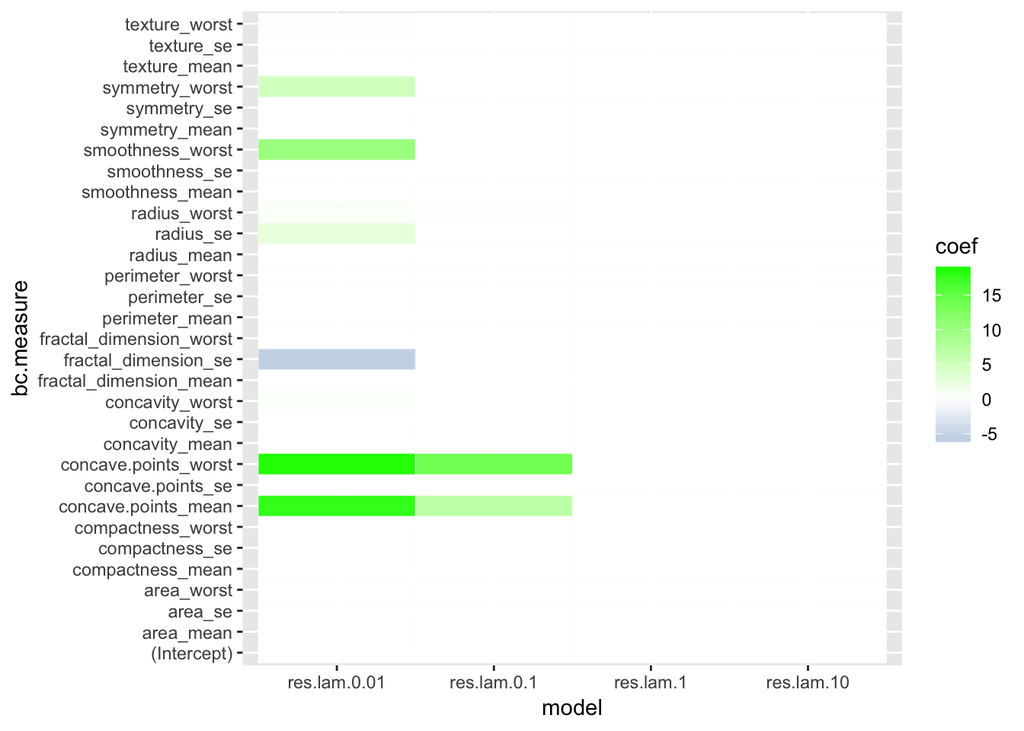

```r
library(tidyverse)
library(scales)

#Put rowname as its own column
res_coefs2 <- rownames_to_column(res.coefs)

#rename it
colnames(res_coefs2)[1] <- 'model'

#Melt it
res_coefs2 <- gather( res_coefs2[-1,], key = bc.measure, value = coef, -model)

#Plot heatmap
p <- ggplot(res_coefs2, aes(x=model, y=bc.measure)) + geom_tile(aes(fill = coef),
     colour = "white") + scale_fill_gradient2(low = "steelblue",
     high = "green", mid = "white")
p
```

Again, as lambda increase (left to right), we get more white, which is around 0.

#### Run prediction of non-regularized model vs test set

```r
# append predictions onto test, as numeric, in a df
X.test <- model.matrix(formula.lm, data = bc.test)
test.res.no.reg <- as.data.frame( as.double( predict(bc.logreg, newx = X.test, type="class") ) )

colnames(test.res.no.reg) <- c('res.no.reg')

# Bind it to the the training set
bc.test <- cbind( bc.test, test.res.no.reg )
```

#### Run prediction of regularized models vs test set

```r
test.res.lasso <- predict(bc.lasso, newx = X.test, type="class")

# Remove the dimnames
test.res.lasso <- unname(test.res.lasso)

# Coerce to numeric
test.res.lasso <- apply(test.res.lasso, 2, as.double)

# turn into df
test.res.lasso <- as.data.frame(test.res.lasso)

# make readable names for predictions
ll <- as.character(bc.lasso$lambda)
prefix <- rep.int('res.lam.',4)
new.names <- paste0(prefix , ll)
colnames(test.res.lasso) <- new.names

# Finally, bind the results to training set
bc.test <- cbind( bc.test, test.res.lasso )
```

#### Calculate prediction accuracy of all the models on test set.

We’ll use a custom function for accuracy.

```r
accuracy = function(truth, pred) {
  # confusion matrix
  cmat = table(truth, pred)
  sum(diag(cmat))/sum(cmat)
}

accuracy( bc.test$target, bc.test$res.no.reg )
```

```
## [1] 0.9646018
```

```r
accuracy( bc.test$target, bc.test$res.lam.0.01 )
```

```
## [1] 0.9557522
```

```r
accuracy( bc.test$target, bc.test$res.lam.0.1 )
```

```
## [1] 0.9292035
```

```r
accuracy( bc.test$target, bc.test$res.lam.1 )
```

```
## [1] 0.6283186
```

```r
accuracy( bc.test$target, bc.test$res.lam.10 )
```

```
## [1] 0.6283186
```

Interesting that the non-regularized model is pretty accurate. As lambda increases, accuracy goes down. Makes sense because we keep ‘removing’ more variables as lambda increases.

For another point of view, here’s a cross-validation plot on the training data, based on the four lambdas.

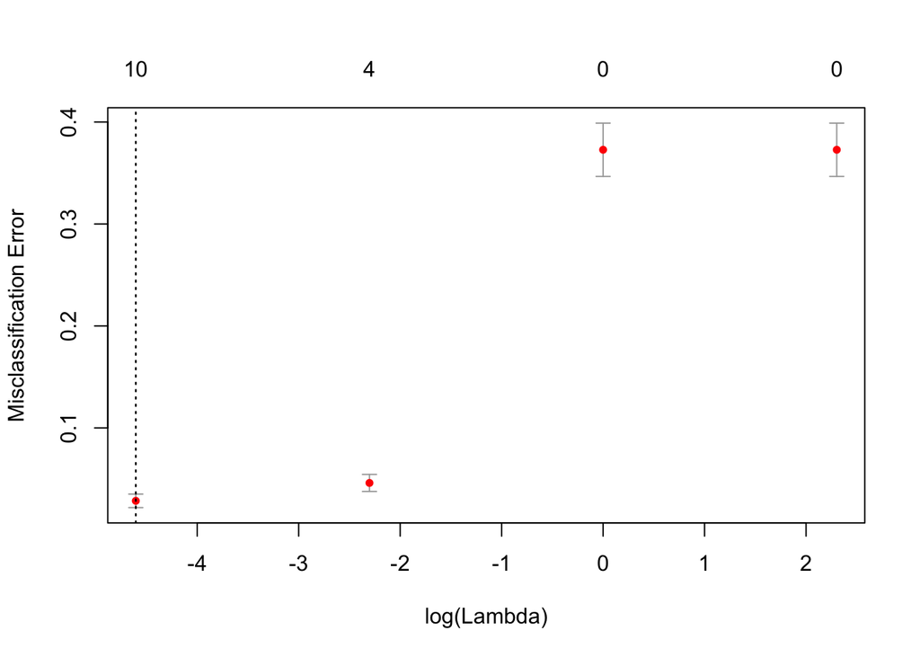

```r
cvfit = cv.glmnet(X, y = bc.train$target, family = "binomial", type.measure = "class", lambda = lambdas)
plot(cvfit)
```

The dotted line indicates the lambda that minimized out-of-sample loss.